# Jun_Accur_3

Andrey Povaliy

2023-09-04

# Диагностическая эффективность автоматизированного УЗИ всей молочной железы при раке молочной железы у пациенток до 40 лет.

## Введение

Рак молочной железы является наиболее распространенным раком среди женщин во всем мире [2]. В США у одной из 196 женщин диагностируется рак молочной железы в возрасте до 40 лет. В западной литературе принято использовать термин Подростки и молодые женщины (ПиМЖ[^1]), то есть пациентки в возрасте 15–39 лет [3]. ПиМЖ чаще, чем женщины старшего возраста, имеют агрессивные подтипы и позднюю стадию заболевания, и при постановке диагноза они часто требуют системного определения стадии [3]. Риск смерти от рака молочной железы увеличивается на 5% на каждый год снижения возраста на момент постановки диагноза, что отражает более агрессивные фенотипы, чем рак молочной железы, возникающий в более позднем возрасте [4]. Поскольку рак молочной железы среди молодых женщин коррелирует с плохой выживаемостью [4], раннее выявление потенциально может улучшить выживаемость, менее инвазивное лечение и более высокое качество жизни, тем самым снижая бремя болезни и затраты на лечение. Однако к вопросам скрининка у ПиМЖ нужно относиться осторожно. Маммография остается золотым стандартом скрининга рака молочной железы. Однако маммография имеет меньшая чувствительность при выявлении рака молочной железы у женщин с плотной грудью, особенно если речь идет о ПиМЖ [5]. Согласно исследованиям, скрининг с помощью ручного ултразвукового исследования (УЗИ[^2]) в дополнение к маммографии у женщин с плотной грудью продемонстрировал увеличение показателей выявления рака молочной железы, которые варьировались от 1,8 до 4,6 случаев рака на 1000 обследованных женщин, в зависимости от стратификации населения по риску [5,6]. Однако исследования программ скрининга в Дании у ПиМЖ [7] с включением маммографии (ММГ[^3]) показали снижение смертности, объясняется это изменениями факторов риска и улучшением лечения, а не скрининговой ММГ. Однако УЗИ имеет ограничения, а имеено отсутствие стандартизации метода, требуемый высокий уровень навыков и опыта, затраты времени [8]. Поэтому для скрининга рака молочной железы было разработано новое поколение автоматизированного объемного сканирования молочных желез (ABUS[^4]). Новое поколение ABUS предлагает автоматическое сканирование молочной железы с помощью датчика с большим полем обзора, позволяющего получать изображения с высоким разрешением. Между тем, форма зонда специально разработана с учетом нормальной кривизны молочной железы, сводя к минимуму индуцированные артефакты на периферии [9,10]. На сегодняшний день ABUS является потенциалом развития в направлениии развития скрининга рака молочножелезы, в частности у ПиМЖ.

## Цель исследования

Провести сравнительный анализ диагностической эффективности (чувствительности, специфичности и точности) УЗИ в B-режиме и автоматизированного объемного сканирования молочных желез (ABUS), и комбинации этих методик у женщин в возрастной группе до 39 лет с высокой плотностью тканей молочной железы.

## Материалы и методы

*Последовательность проведения диагностики*

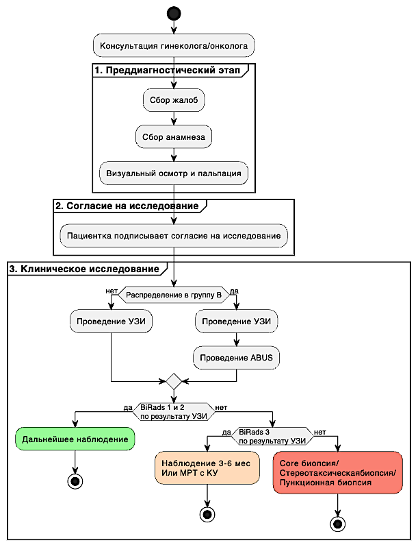

При обращении пациентки пациентки к гинеколону или онкологу проводился сбор жалоб, анамнеза и осмтор, полученные данные регистрировались в карте пацинта. Далее пациентке предлагалось пройти обследование в рамках настоящего исследовани и после получения согласия проводилась распределние по группам в случайнос порядке, а имеено простым жребием. С условием увеличения выборок жребий корректировался для сохранения пропорции. Пациентки попавшие в группу А проходили УЗИ с последующей установкой категории BiRads. Пациентки попавшие в группу B в дополнение проходили ABUS также с определением категории BiRads по УЗИ.

Пациенткам, котрым по результатам УЗИ исследования были выставлены категории BiRads 1 и BiRads 2 было рекомендовано дальнейшее наблюдение. При усановке категории BiRads 3 было рекомендовано наблюдение в течении 3-6 мес или МРТ с КУ. При категории BiRads 4 и BiRads 5 проводилась core биопсия или стереотаксическая биопсия или пункционная биопсия. Все данные регистрировались для дальнейшего анализа.

*Описание выборки и групп*

Жалоб в группе A не было в 86.79% (683), жалобы на уплотнение в 8.01% (63)  
на боль в 4.83% (38) и на выделение из соска в 0.38% (3). В группе B жалоб не было нет в 82.87% (600), жалобы уплотнение в 10.91% (79), на боль в 5.25% (38) и выделения из соска в 0.97% (7)

В группе A в репродуктивном возрасте было 96.7% (761) и пременопауза в 3.3% (26), а в группе B в репродуктивном возрасте было 97.24% (704) случаев и в 2.76% (20) была пременопауза.

Операции на молочной железе в группе A были в 1.52% (12), а в группе B были операции в 1.66% (12). В иных случаях операций не было.

Прием гормональных препаратов в группе A был в 19.7% (155), а в группе B в 21.41% (155)

Наследственная предрасположенность в группе A в в 31% (244), а В группе B в 31.08% (225).

В группе A было 6 исследований мутации BRCA и была найдена мутация BRCA1 в 100% (6), в группе B мутаций не выявлено в всех 100% (18) слкчаев.

Кожные симптомтомов в обеих группах не было.

В группе A не наблюдался симптом втягивания соска. В группе B были случаи с указанным симптомом в 2.49% (18).

В группе A в 0.89% (7) были кровянистые выделения из соска, в 99.11% (780) никаких выделений не было. В группе B во всех случаях не было выделений.

По типу структуры ACR в группе A тип С был в 72.94% (574), а тип D в 27.06% (213), в то время как в группе B тип С был в 67.82% (491), а тип D в 32.18% (233).

Таблица № 1. Основные характеристики пациенток, прошедших исследование

| Группы | Группа A | —— | Группа B | —— |
| --- | --- | --- | --- | --- |
| **Жалобы** |  |  |  |  |
| без жалоб | 86.785 % ( 683 / 787 случаев) | [ 0.84 ; 0.89 ] | 82.873 % ( 600 / 724 случаев) | [ 0.8 ; 0.86 ] |
| боль | 4.828 % ( 38 / 787 случаев) | [ 0.03 ; 0.07 ] | 5.249 % ( 38 / 724 случаев) | [ 0.04 ; 0.07 ] |
| выделения из соска | 0.381 % ( 3 / 787 случаев) | [ 0 ; 0.01 ] | 0.967 % ( 7 / 724 случаев) | [ 0 ; 0.02 ] |
| уплотнение | 8.005 % ( 63 / 787 случаев) | [ 0.06 ; 0.1 ] | 10.912 % ( 79 / 724 случаев) | [ 0.09 ; 0.13 ] |
| **Репродуктивный статус** |  |  |  |  |
| репродуктивный возраст | 96.696 % ( 761 / 787 случаев) | [ 0.95 ; 0.98 ] | 97.238 % ( 704 / 724 случаев) | [ 0.96 ; 0.98 ] |
| пременопауза | 3.304 % ( 26 / 787 случаев) | [ 0.02 ; 0.05 ] | 2.762 % ( 20 / 724 случаев) | [ 0.02 ; 0.04 ] |
| **Операции на молочной железе** |  |  |  |  |
| не было операций | 98.475 % ( 775 / 787 случаев) | [ 0.97 ; 0.99 ] | 98.343 % ( 712 / 724 случаев) | [ 0.97 ; 0.99 ] |
| были операции | 1.525 % ( 12 / 787 случаев) | [ 0.01 ; 0.03 ] | 1.657 % ( 12 / 724 случаев) | [ 0.01 ; 0.03 ] |
| **Прием гормональных препаратов** |  |  |  |  |
| да | 19.695 % ( 155 / 787 случаев) | [ 0.17 ; 0.23 ] | 21.409 % ( 155 / 724 случаев) | [ 0.19 ; 0.25 ] |
| нет | 80.305 % ( 632 / 787 случаев) | [ 0.77 ; 0.83 ] | 78.591 % ( 569 / 724 случаев) | [ 0.75 ; 0.81 ] |
| **Наследственная предрасположенность** |  |  |  |  |
| есть | 31.004 % ( 244 / 787 случаев) | [ 0.28 ; 0.34 ] | 31.077 % ( 225 / 724 случаев) | [ 0.28 ; 0.35 ] |
| нет | 68.996 % ( 543 / 787 случаев) | [ 0.66 ; 0.72 ] | 68.923 % ( 499 / 724 случаев) | [ 0.65 ; 0.72 ] |
| **Мутация BRCA** |  |  |  |  |
| BRCA1 | 100 % ( 6 / 6 случаев) | [ 0.52 ; 1 ] | 0 % ( 0 / 18 случаев) | [ 0 ; 0.22 ] |
| мутаций не выявлено | 0 % ( 0 / 6 случаев) | [ 0 ; 0.48 ] | 100 % ( 18 / 18 случаев) | [ 0.78 ; 1 ] |
| **Симптом втягивания соска** |  |  |  |  |
| да | 0 % ( 0 / 787 случаев) | [ 0 ; 0.01 ] | 2.486 % ( 18 / 724 случаев) | [ 0.02 ; 0.04 ] |
| нет | 100 % ( 787 / 787 случаев) | [ 0.99 ; 1 ] | 97.514 % ( 706 / 724 случаев) | [ 0.96 ; 0.98 ] |
| **Симптом выделения из соска** |  |  |  |  |
| нет | 99.111 % ( 780 / 787 случаев) | [ 0.98 ; 1 ] | 100 % ( 724 / 724 случаев) | [ 0.99 ; 1 ] |
| кровянистые | 0.889 % ( 7 / 787 случаев) | [ 0 ; 0.02 ] | 0 % ( 0 / 724 случаев) | [ 0 ; 0.01 ] |
| **Тип структуры ACR** |  |  |  |  |
| С | 72.935 % ( 574 / 787 случаев) | [ 0.7 ; 0.76 ] | 67.818 % ( 491 / 724 случаев) | [ 0.64 ; 0.71 ] |
| D | 27.065 % ( 213 / 787 случаев) | [ 0.24 ; 0.3 ] | 32.182 % ( 233 / 724 случаев) | [ 0.29 ; 0.36 ] |

*Описание ABUS*

3D-автоматизированная ультразвуковая система Invenia (ABUS) оцениваемая в данном исследовании, производства GE Healthcare (Саннивейл, Калифорния, США) 2018 года выпуска— это компьютерная система для оценки плотной молочной железы. Каждая молочная железа была визуализирована в трех проекциях: боковой (LAT), переднезадней (AP).и медиальный (MED) с автоматическим датчиком с линейной матрицей от 6 до 14 МГц, прикрепленным к жесткой компрессионной пластине (площадь 15,4×17,0×5,0 см).Индивидуальная мембрана для датчика была использована для каждой пациентки. Во время исследования система получала до 300 2D-срезов и реконструировала их в коронарной плоскости. Стандартизированный процесс осмотра включает использование запатентованной коронарной плоскости для быстрой навигации по молочной железе, а также использование «режима обзора», позволяющего врачу быстро интерпретировать изображения. Время сбора данных для каждой проекции составляло 60 с, примерно по 3–4 мин на каждую молочную железу.

Обследование проводили в положении лежа. Полотенце было помещено под плечом, что помогло расправить ткань молочной железы равномерно, соском к потолку. На молочные железы равномерно наносили гипоаллергенный ультразвуковой гель с дополнительным количество на область соска. Возможно применение трех уровней компрессии датчика для исследования молочных желез для получения наилучшей визуализации с учетом комфорта пациента.

Сканирование ABUS было непрерывным и автоматизированным. В течение исследования женщин попросили не двигаться, не разговаривать и дышать ровно. Выполнял исследование сертифицированный персонал со средним медицинским образованием.

*Описание УЗИ-исседования*

УЗИ мсследование выполняли два врача ультразвуковой диагностики со стажем работы более 7 лет. Исследование проводилось в положении лежа, с руками за головой, с последовательным сканированием каждого квадранта обеих молочных железе в сагитальной и аксиальной плоскостях, с исследованием ретроареолярной области и аксиллярных областей с двух сторон.

Устройства, используемые для проведения HHUS включали GE LOGIQS 8 (GE Medical Systems, Милуоки, Висконсин, США), Toshiba Aplio 300(Canon Япония)- ультразвуковые системы экспертного класса.

*Статистический анализ*

Обозначения p1 и p2 соответствуют сравниваемым пропорциям. Данные, необходимые для расчета величины эффекта были взяты из исследования Xin Y. и коллег (2021) [10]. Получено значение умножалось на 1.15 (то есть +15%), чтобы учесть возможность устранения неподходящих к исследованию данных с сохранением необходимого объема. По результатам расчета для достижения эффекта нужно исследовать не менее 1430 пациенток, в настоящем исследовании было на 5.66% больше от необходимого.

Для описания количественных показателей проводилась оценка на нормальность распределения, в качестве метода использовался критерий Шапиро-Уилка. Переменные, имеющие нормальное распределение, описывались как среднее ± стандартное отклонение (M±SD). Переменные, распределение которых отличалось от нормального, описывались при помощи значений медианы (Me) и нижнего и верхнего квартилей (Q1-Q3). Для определения статистически значимой разницы непрерывных величин использовали критерий Манна-Уитни для независимых непараметрических выборок при ненормальном распределении и t-критерий Стюдента для независимых параметрических выборок при нормальном. Для определения статистически значимой разницы независимых качественных величин Хи-квадрат Пирсона, при недостаточном количестве наблюдений, то есть число наблюдений в любой из ячеек четырехпольной таблицы было менее 5 наблюдений, использовался точный критерий Фишера.

Для построения предсказательной модели на основании данных использовалась логистическая регрессия с помощью функций glm (), predict() из пакета stats версия 3.6.2, язык программирования R (среда разработки RStudio). Для оценки получено предсказательной модели и построения ROC-кривой с расчетом площади под кривой (AUC - area under curve) использовался пакет pROC version 1.18.4 с функцией roc().

## Результаты исследования

По результатам выполнения УЗИ в группе A Birads 1 в 26.68% (210), Birads 2 в 57.69% (454), Birads 3 в 12.45% (98), Birads 4а в 1.27% (10) и Birads 5 в 1.91% (15) В группе B категория Birads 1 в 20.58% (149),Birads 2 в 58.43% (423),Birads 3 в 15.19% (110),Birads 4а в 3.31% (24),Birads 4b в 1.66% (12) и Birads 5 в 0.83% (6) (Рисунок №2)

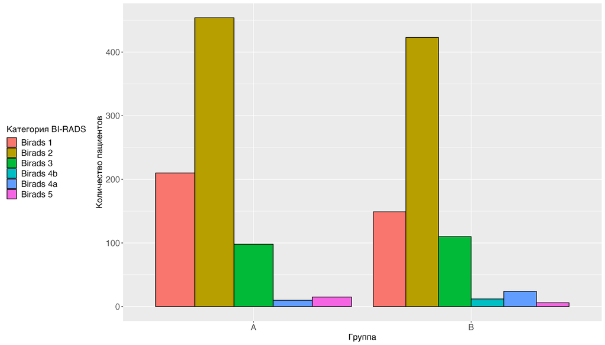

Рисунок №2. Распределение поставленных категорий BiRads после выполнения УЗИ

*Определение чувствительности, спецефичности и точности методов*

При оценке УЗИ в группе А количество истинно верно определенных образований как доброкачественные было 769 , количество верно определённых образований как злокачественные было 12 , количество неверно определенных образований как злокачественные было 3 и количество неопределенных злокачественных образований как доброкачественные было 3 . Точность метода составила 0.99 [95% ДИ: 0.98 , 1 ]. P-Value модели составил 0.01 что означает, что модель отличается от точности нулевой гипотезы. Коэфициент Kappa составил 0.8 показывает, что метод указывает на высокое согласие между предсказаниями и истинными значениями (количество истинно положительных и отрицательных результатов). Тест Макнемара составил 1 показывает, что метод не имеет существенно отличную от контрольного метода частоту ошибок (количество ложноположительных и ложноотрицательных результатов). Чувствительность метода составила 0.8. Специфичность метода составила 1. Отбалансированная точность метода составила 0.9

При оценке УЗИ в группе B количество истинно верно определенных образований как доброкачественные было 673 , количество верно определённых образований как злокачественные было 33 , количество неверно определенных образований как злокачественные было 14 и количество неопределенных злокачественных образований как доброкачественные было 4. Точность метода составила 0.98 [95% ДИ: 0.96 , 0.99]. P-Value модели составил < 0,01 что означает, что модель отличается от точности нулевой гипотезы. Коэфициент Kappa составил 0.77 показывает (если стремится к 1), что метод указывает на высокое согласие между предсказаниями и истинными значениями (количество истинно положительных и отрицательных результатов). Тест Макнемара составил 0.03 показывает, что метод имеет существенно отличную от контрольного метода частоту ошибок, тоесть метод УЗИ был больше в сторону количества ложноположительных результатов. Чувствительность метода составила 0.89. Специфичность метода составила 0.98. Отбалансированная точность метода составила 0.94

При оценке ABUS в группе B количество истинно верно определенных образований как доброкачественные было 678 , количество верно определённых образований как злокачественные было 35 , количество неверно определенных образований как злокачественные было 9 и количество неопределенных злокачественных образований как доброкачественные было 2 . Точность метода составила 0.98 [95% ДИ: 0.97 , 0.99 ]. P-Value модели составил < 0,01 что означает, что модель отличается от точности нулевой гипотезы. Коэфициент Kappa составил 0.86 показывает, что метод указывает на высокое согласие между предсказаниями и истинными значениями (количество истинно положительных и отрицательных результатов). Тест Макнемара составил 0.07 показывает, что метод не имеет существенно отличную от контрольного метода частоту ошибок (количество ложноположительных и ложноотрицательных результатов). Чувствительность метода составила 0.95 . Специфичность метода составила 0.99. Отбалансированная точность метода составила 0.97.

При оценке УЗИ в выборке пациенток до 40 лет количество истинно верно определенных образований как доброкачественные было 1442 , количество верно определённых образований как злокачественные было 45 , количество неверно определенных образований как злокачественные было 17 и количество неопределенных злокачественных образований как доброкачественные было 7 . Точность метода составила 0.98 [95% ДИ: 0.98 , 0.99 ]. P-Value модели составил < 0,01 что означает, что модель отличается от точности нулевой гипотезы. Коэфициент Kappa составил 0.78 показывает , что метод указывает на высокое согласие между предсказаниями и истинными значениями (количество истинно положительных и отрицательных результатов). Тест Макнемара составил 0.07 показывает, что метод не имеет существенно отличную от контрольного метода частоту ошибок (количество ложноположительных и ложноотрицательных результатов). Чувствительность метода составила 0.87 . Специфичность метода составила 0.99. Отбалансированная точность метода составила 0.93. (Таблица №2)

Таблица №2. Определение точности, P-уровня значимости модели, коэфициент Kappa, Тест Макнемара, чувствительности, специфичности и отбалансированной точности в группах А и B. (Т -Точность, P - P-Value, КК - Коэффициент Kappa, ТМ -Тест Макнемара, Ч-Чувствительность, Сп -Специфичность, ОТ- Отбалансированная точность)

| Метод | Т | P | КК | ТМ | Ч | Сп | ОТ |
| --- | --- | --- | --- | --- | --- | --- | --- |
| УЗИ в группе А | 0.99 [95% ДИ: 0.98 , 1 ]. | 0.01 | 0.8 | 1 | 0.8 | 1 | 0.9 |
| УЗИ в группе B | 0.98 [95% ДИ: 0.96 , 0.99 ]. | 0 | 0.77 | 0.03 | 0.89 | 0.98 | 0.94 |
| ABUS в группе B | 0.98 [95% ДИ: 0.97 , 0.99 ]. | 0 | 0.86 | 0.07 | 0.95 | 0.99 | 0.97 |
| УЗИ в выборке пациенток до 40 лет | 0.98 [95% ДИ: 0.98 , 0.99 ]. | 0 | 0.78 | 0.07 | 0.87 | 0.99 | 0.93 |

*Прогностическая оценка методов*

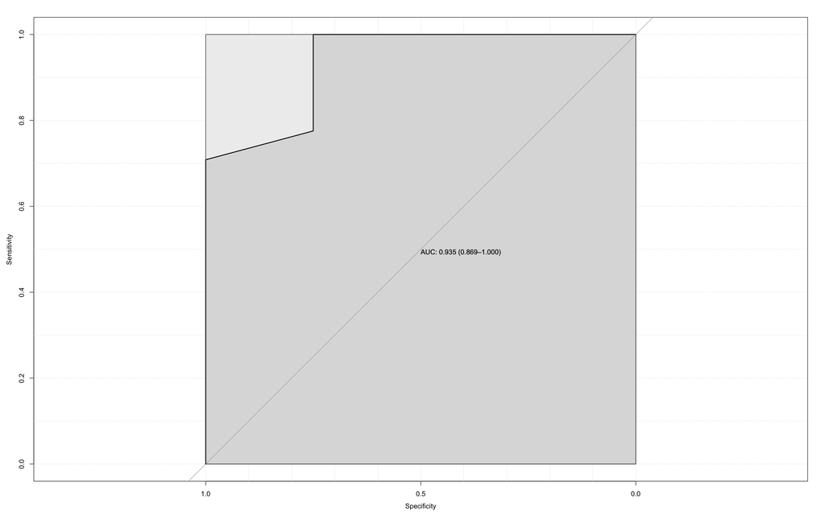

Рисунок №2а. ROC-кривая предсказательной модели для метода УЗИ, по данным полученным в группе A. ROC-кривая предсказательной модели для метода УЗИ, по данным полученным в группе B представлена на рисунке № 2б. Площадь под кривой (AUC- area under cruve) составила: 0.903 95% ДИ: 0.82 - 0.986.

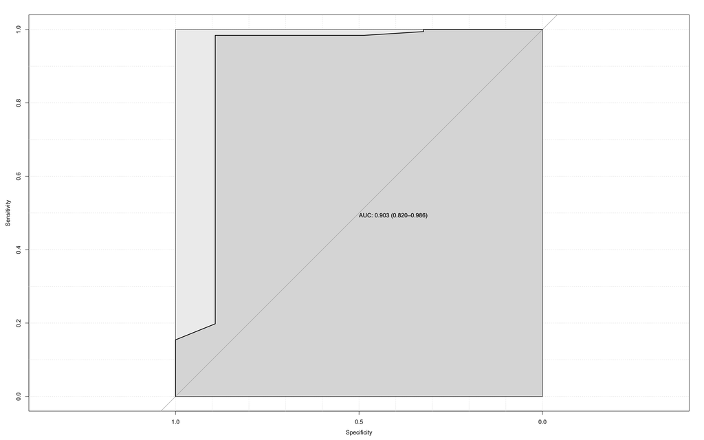

Рисунок №2б. ROC-кривая предсказательной модели для метода УЗИ, по данным полученным в группе B. ROC-кривая предсказательной модели для метода ABUS, по данным полученным в группе B представлена на рисунке № 2в. Площадь под кривой (AUC- area under cruve) составила: 0.968 95% ДИ: 0.925 - 1

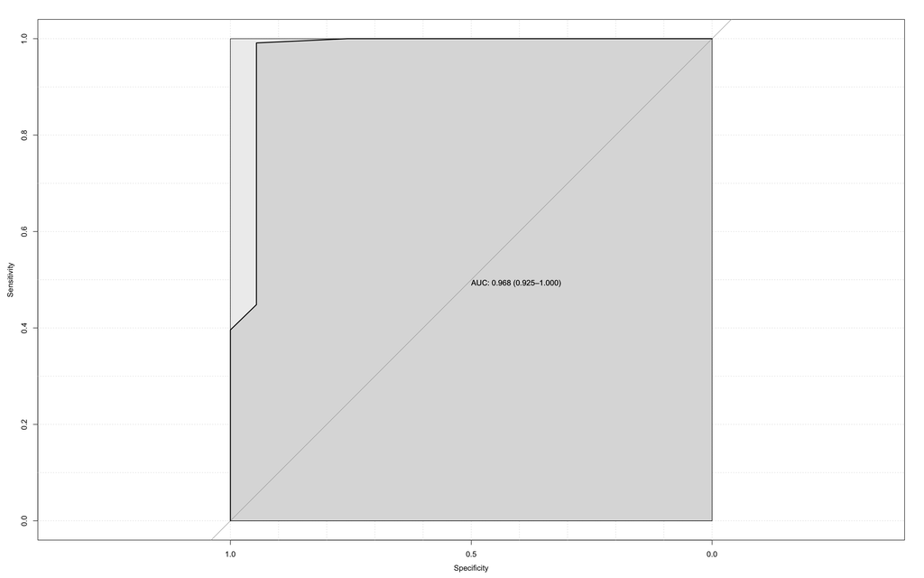

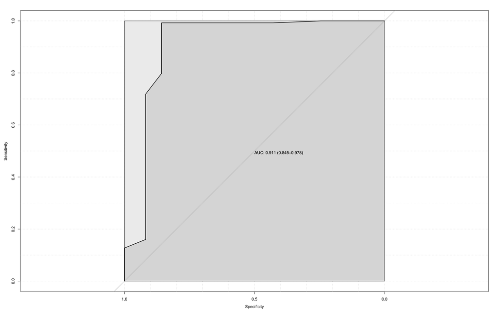

Рисунок №2г. ROC-кривая предсказательной модели для метода УЗИ, по данным полученным в выборке пациенток до 40 лет.

Таблица №3.

Определение площади под кривой представленных предсказательных моделей метода в группах А и B.

[output not shown]

## Дисскусия

На базе нашего дигностического центра получилось достаточное по обхему выборок исследование для определния диагностической эффективности. Мы определили, что ABUS имеет более высокую чувтвительность и отбалансированную точность и сопоставимую специфичность по сравнению с выполнением УЗИ. Наше исследование имело специфику раннего выявления рака молочной жедезы в выборке пациенток до 40 лет.

По оценкам, в США зарегистрировано 12 150 случаев рака молочной железы. Состояния будут диагностировать у женщин в возрасте до 40 лет, а примерно 26 393 будут у женщин в возрасте до 45 лет. [11]. Ежегодно умирает более 1000 женщин в возрасте до 40 лет. в США от рака молочной железы [12].

Раннее выявление снижает смертность среди женщин с раком молочной железы [13]. В настоящее время ACR рекомендует ежегодно маммографический скрининг, начиная с 40 лет для женщины со средним риском развития рака молочной железы, на основании обширного обзора литературы [13]. Женщины с дополнительными факторами риска, подвергающие их риску выше среднего развивающийся рак молочной железы требует дальнейшего рассмотрения более ранний и/или более интенсивный скрининг [13]. Эти женщины в возрасте < 40 лет обычно имеют эквивалентный риск до или выше, чем у женщины среднего риска в возрасте 40 лет.

На сегодняшний день существуют перимущественно зарубежные исследования, продемонстрировали аналогичную диагностическую эффективность ABUS по сравнению с УЗИ, но в целом общие результаты были противоречивыми. В некоторых исследованиях сообщалось, что ABUS имеет более высокую чувствительность от 95 до 100% и более низкую специфичность от 58 до 95% [14–16]. Напротив, другие показали, что УЗИ продемонстрировал превосходную чувствительность , в то время как ABUS продемонстрировал несколько более высокую специфичность [17,18].

В некоторых исследованиях авторы указывают две причины более низкой чувствительности ABUS. Во-первых, у рентгенологов было мало опыта интерпретации изображений ABUS [19,20]. Одно исследование также показало, что все пропущенные рака, пропущенные, можно было продемонстрировать в ретроспективном анализе [21]. Во-вторых, ABUS мог пропустить поражения из-за плохого качества изображения [21]. В нашем центре можно констатировать, что качество изображений на высоком уровне. Техники группы ABUS прошли достаточную подготовку, чтобы гарантировать качество получения и интерпретации изображений, специалисты УЗИ имеют высокий квалификационный уровень. Можно обратить внимание, что более короткий срок обучения для выполнеия ABUS имеют сопоставимую диагностическую эффективность с выполгнением УЗИ. Это подчеркивает преимущества ABUS перед УЗИ: ABUS менее зависит от оператора и может снизить рабочую нагрузку рентгенологов за счет обучения квалифицированных технических специалистов. Настояще исследование имеет важное ограничение, а именно исследование является одноцентровым. Безусловно требуется проведение многоцентровых исследований с оценко качества проведения подготовки специалистов на всех уровнях проведения диагностки.

## Выводы

Согласно проведенному нами исследованию диагностическая эффективность автоматизированного УЗИ всей молочной железы при раке молочной железы у пациенток до 40 лет достоверно не хуже проведения классического УЗИ исследования.

## Список литературы

1.

Shapira N. The potential contribution of dietary factors to breast cancer prevention. *European Journal of Cancer Prevention*. 2017;26(5):385-395. doi:10.1097/cej.0000000000000406

2.

Kocarnik JM, Compton K, Dean FE, et al. Cancer incidence, mortality, years of life lost, years lived with disability, and disability-adjusted life years for 29 cancer groups from 2010 to 2019: A systematic analysis for the global burden of disease study 2019. *JAMA oncology*. 2022;8(3):420-444.

3.

Cathcart-Rake EJ, Ruddy KJ, Bleyer A, Johnson RH. Breast Cancer in Adolescent and Young Adult Women Under the Age of 40 Years. *JCO Oncology Practice*. 2021;17(6):305-313. doi:10.1200/op.20.00793

4.

Desreux JAC. Breast cancer screening in young women. *European Journal of Obstetrics & Gynecology and Reproductive Biology*. 2018;230:208-211. doi:10.1016/j.ejogrb.2018.05.018

5.

Nazari SS, Mukherjee P. An overview of mammographic density and its association with breast cancer. *Breast Cancer*. 2018;25(3):259-267. doi:10.1007/s12282-018-0857-5

6.

Scheel JR, Lee JM, Sprague BL, Lee CI, Lehman CD. Screening ultrasound as an adjunct to mammography in women with mammographically dense breasts. *American Journal of Obstetrics and Gynecology*. 2015;212(1):9-17. doi:10.1016/j.ajog.2014.06.048

7.

Jorgensen KJ, Zahl P-H, Gotzsche PC. Breast cancer mortality in organised mammography screening in Denmark: comparative study. *BMJ*. 2010;340(mar23 1):c1241-c1241. doi:10.1136/bmj.c1241

8.

Rebolj M, Assi V, Brentnall A, Parmar D, Duffy SW. Addition of ultrasound to mammography in the case of dense breast tissue: systematic review and meta-analysis. *British Journal of Cancer*. 2018;118(12):1559-1570. doi:10.1038/s41416-018-0080-3

9.

Vourtsis A, Kachulis A. The performance of 3D ABUS versus HHUS in the visualisation and BI-RADS characterisation of breast lesions in a large cohort of 1,886 women. *European Radiology*. 2017;28(2):592-601. doi:10.1007/s00330-017-5011-9

10.

Xin Y, Zhang X, Yang Y, et al. A multicenter, hospital-based and non-inferiority study for diagnostic efficacy of automated whole breast ultrasound for breast cancer in China. *Scientific Reports*. 2021;11(1). doi:10.1038/s41598-021-93350-1

11.

Kaminsky O, Zilbermints V, Sharon E, Aranovich D, et al. Young woman in the breast clinic: Ultrasound or not? *The Israel Medical Association Journal: IMAJ*. 2019;21(9):612-614.

12.

Anders CK, Fan C, Parker JS, et al. Breast Carcinomas Arising at a Young Age: Unique Biology or a Surrogate for Aggressive Intrinsic Subtypes? *Journal of Clinical Oncology*. 2011;29(1):e18-e20. doi:10.1200/jco.2010.28.9199

13.

Monticciolo DL, Newell MS, Moy L, Niell B, Monsees B, Sickles EA. Breast Cancer Screening in Women at Higher-Than-Average Risk: Recommendations From the ACR. *Journal of the American College of Radiology*. 2018;15(3):408-414. doi:10.1016/j.jacr.2017.11.034

14.

Lin X, Wang J, Han F, Fu J, Li A. Analysis of eighty-one cases with breast lesions using automated breast volume scanner and comparison with handheld ultrasound. *European Journal of Radiology*. 2012;81(5):873-878. doi:10.1016/j.ejrad.2011.02.038

15.

Wang HY, Jiang YX, Zhu QL, et al. Differentiation of benign and malignant breast lesions: A comparison between automatically generated breast volume scans and handheld ultrasound examinations. *European Journal of Radiology*. 2012;81(11):3190-3200. doi:10.1016/j.ejrad.2012.01.034

16.

Kotsianos-Hermle D, Wirth S, Fischer T, Hiltawsky KM, Reiser M. First clinical use of a standardized three-dimensional ultrasound for breast imaging. *European Journal of Radiology*. 2009;71(1):102-108. doi:10.1016/j.ejrad.2008.04.002

17.

Kim SH, Kang BJ, Choi BG, et al. Radiologists’ Performance for Detecting Lesions and the Interobserver Variability of Automated Whole Breast Ultrasound. *Korean Journal of Radiology*. 2013;14(2):154. doi:10.3348/kjr.2013.14.2.154

18.

Prosch H, Halbwachs C, Strobl C, et al. Automatisierter Brustultraschall vs. handgeführter Brustultraschall: BI-RADS-Einstufung, Untersuchungsdauer und Erlebnisqualität der Untersuchung. *Ultraschall in der Medizin - European Journal of Ultrasound*. 2011;32(05):504-510. doi:10.1055/s-0031-1273414

19.

Skaane P, Gullien R, Eben EB, Sandhaug M, Schulz-Wendtland R, Stoeblen F. Interpretation of automated breast ultrasound (ABUS) with and without knowledge of mammography: a reader performance study. *Acta Radiologica*. 2015;56(4):404-412. doi:10.1177/0284185114528835

20.

Chen L, Chen Y, Diao XH, et al. Comparative Study of Automated Breast 3-D Ultrasound and Handheld B-Mode Ultrasound for Differentiation of Benign and Malignant Breast Masses. *Ultrasound in Medicine & Biology*. 2013;39(10):1735-1742. doi:10.1016/j.ultrasmedbio.2013.04.003

21.

Lin X, Jia M, Zhou X, et al. The diagnostic performance of automated versus handheld breast ultrasound and mammography in symptomatic outpatient women: a multicenter, cross-sectional study in China. *European Radiology*. 2020;31(2):947-957. doi:10.1007/s00330-020-07197-7

[^1]: ПиМЖ - подростки и молодые женщины, термен является точным переводом “adolescent and young adults”, термин используется в ангоязычной литертуре, в частности в публикациях системы здравоохранения США
[^2]: УЗИ - ручного ультразвуковое исследование
[^3]: ММГ - маммография
[^4]: ABUS - автоматизированное объемное УЗИ сканирования молочных желез от англ. “3D automated breast ultrasound”